# Project 3: Text Analytics

Ari Boyarsky, Isaac Gritz, Abdul Sheikhnureldin, Sameer Rau, Clare Lohrmann

December 16, 2016

## Part 1

*Please note that we use the `head` command in multiple places to limit the size of this file for clairty. If you would like to see the unabridged version please look at the file `PartB.R` in the zip file.*

First we get all the libraries needed.

```r
# libraries
library(tm)  # Framework for text mining.
library(qdap)  # Quantitative discourse analysis of transcripts.
library(qdapDictionaries)
library(dplyr)  # Data wrangling, pipe operator %>%().
library(RColorBrewer)  # Generate palette of colours for plots.
# library(ggplot2) # Plot word frequencies.
library(scales)  # Include commas in numbers.
library(quanteda)  # quantitative manip of corpus
library(textreuse)  # text analytic feature sets


# get data
data(acq)
```

### Part A

Functions created:

`doc_search`: Enter data and a search strind and the function will return the document number, word index, and line number of the string.

We use the following functions to help comoute the results:

`inspect`: This function ispects the contents of an R Object

`findFreqTerms`: this function returns the frequency of terms in a corpus

`DocumentTermMatrix`: thsi function turns a corpus into a DocumentTermMatrix, which holds the frequency of terms based on a document frequency matrix scheme.

`wordcount`: counts the words in a corpus

`termFreq`: counts term frequency

`findAssocs`: find words that are commonly associated with a term based on a n-gram schema

`tokenize_sentecnes`: breaks a corpus up into its respective sentences

`tokenize_words`: breaks a corpus up into its respective words

`tm_map`: a powerful function from `tm` that allows us to make chnages to a corpus like chnaging it to lowercase, or removing stopwords.

```r
# a: try functions in lecture 7
data(acq)
inspect(head(acq))
```

```
## <<VCorpus>>
## Metadata:  corpus specific: 0, document level (indexed): 0
## Content:  documents: 6
##
## $`reut-00001.xml`
## <<PlainTextDocument>>
## Metadata:  15
## Content:  chars: 1287
##
## $`reut-00002.xml`
## <<PlainTextDocument>>
## Metadata:  15
## Content:  chars: 784
##
## $`reut-00003.xml`
## <<PlainTextDocument>>
## Metadata:  15
## Content:  chars: 502
##
## $`reut-00004.xml`
## <<PlainTextDocument>>
## Metadata:  15
## Content:  chars: 2308
##
## $`reut-00005.xml`
## <<PlainTextDocument>>
## Metadata:  15
## Content:  chars: 337
##
## $`reut-00006.xml`
## <<PlainTextDocument>>
## Metadata:  15
## Content:  chars: 381
```

```r
head(summary(acq), n = 10)
```

```
##     Length Class             Mode
## 10  2      PlainTextDocument list
## 12  2      PlainTextDocument list
## 44  2      PlainTextDocument list
## 45  2      PlainTextDocument list
## 68  2      PlainTextDocument list
## 96  2      PlainTextDocument list
## 110 2      PlainTextDocument list
## 125 2      PlainTextDocument list
## 128 2      PlainTextDocument list
## 134 2      PlainTextDocument list
```

```r
list.acq <- as.list(acq)
require(openNLP)

wordcount(acq[[2]])
```

```
## [1] 131
```

```r
for (i in 1:50) {
    wordcount(content(acq[[i]]))
}

dtm <- DocumentTermMatrix(acq)



termFreq(acq[[1]])
```

```
## txt
##           .125         <sedio        <woodco           1.50        200,000
##              1              1              1              1              2
##         50,000        acquire     additional           also            and
##              1              1              2              2              6
##            any            are           but,            buy        certain
##              1              1              1              1              1
##         change  circumstances         common        company       company.
##              1              1              3              3              1
##      completed       computer     conditions       continue        control
##              1              6              1              1              1
##          costs        current      delivery.           dlrs          dlrs.
##              1              1              1              2              2
##            dot         ensure          equal         exceed      exclusive
##              1              1              1              1              1
##    exercisable           five            for         forms,         future
##              2              1              4              1              1
##      generated            has           help       holdings       houston,
##              1              2              1              1              1
##         impact  improvements,            inc           inc>      including
##              1              1              1              1              1
##       increase      involving            its        labels,       licensee
##              1              1              5              1              1
##        lugano,          makes         market         matrix            mln
##              1              1              1              1              1
##          moves          n.v.>            not          occur            one
##              1              1              1              1              1
##      operation    outstanding           part            pay            pct
##              1              1              1              1              2
##            per           plan          price       printers        product
##              2              1              3              1              1
##       purchase reorganization         reuter          right         rights
##              1              1              1              1              1
##           said           sale          sedio         share.         shares
##              7              1              1              2              2
##        shares,           sold          stock        stock's         stock,
##              1              1              1              1              1
##    switzerland        systems           tags      technolgy     technology
##              1              1              1              1              1
##    technology,       terminal     terminal's     terminals.           tex.
##              1              4              1              1              1
##            the         ticket          time,          total          under
##             15              1              1              1              1
##       warrants           were        woodco.      worldwide          would
##              3              1              1              1              3
##          years
##              1
```

```r
dm2 <- TermDocumentMatrix(acq, control = list(wordLengths = c(1, Inf)))

assoc <- findAssocs(dm2, "states", 0.25)

freq.terms <- findFreqTerms(dm2, lowfreq = 3)
```

### Part B

```r
# b: find 10 longest docs (in words)
inspect(head(acq))
```

```
## <<VCorpus>>
## Metadata:  corpus specific: 0, document level (indexed): 0
## Content:  documents: 6
##
## $`reut-00001.xml`
## <<PlainTextDocument>>
## Metadata:  15
## Content:  chars: 1287
##
## $`reut-00002.xml`
## <<PlainTextDocument>>
## Metadata:  15
## Content:  chars: 784
##
## $`reut-00003.xml`
## <<PlainTextDocument>>
## Metadata:  15
## Content:  chars: 502
##
## $`reut-00004.xml`
## <<PlainTextDocument>>
## Metadata:  15
## Content:  chars: 2308
##
## $`reut-00005.xml`
## <<PlainTextDocument>>
## Metadata:  15
## Content:  chars: 337
##
## $`reut-00006.xml`
## <<PlainTextDocument>>
## Metadata:  15
## Content:  chars: 381
```

```r
dtm <- DocumentTermMatrix(acq)
wordCounts <- rowSums(as.matrix(dtm))
largest <- names(head(sort(wordCounts, decreasing = T), 10))
largest
```

```
##  [1] "110" "362" "496" "372" "302" "45"  "331" "448" "393" "10"
```

### Part C

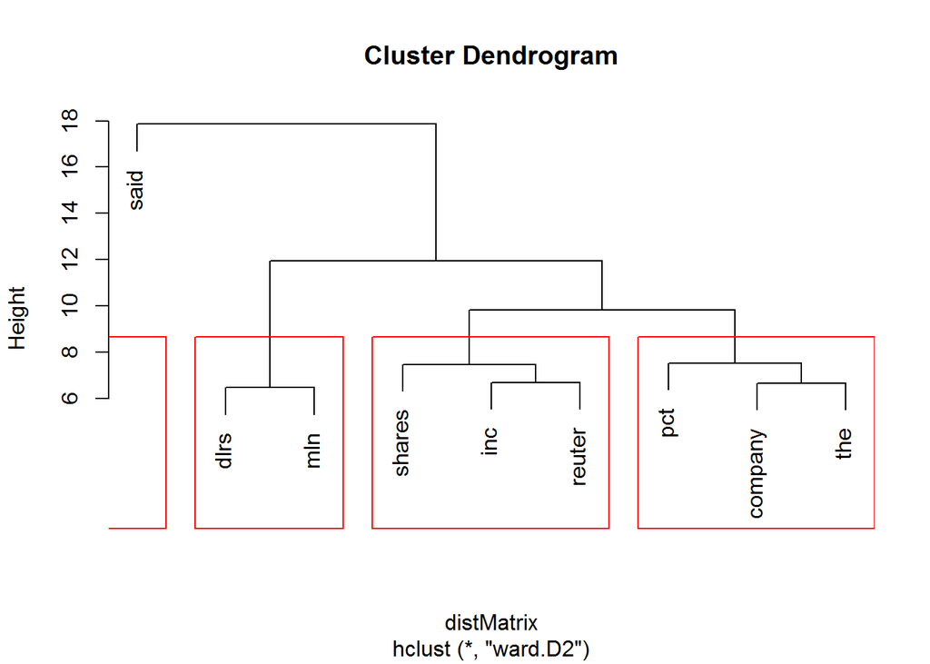

```r
# c: for each doc, work through examples in lect 7 to display dendrogram and
# Wordcloud

# we will do this right and remove stop words
d <- Corpus(VectorSource(acq))
dm3 <- tm_map(d, removeWords, stopwords("english"))

dm2 <- TermDocumentMatrix(dm3)
dm2 <- removeSparseTerms(dm2, sparse = 0.6)
distMatrix <- dist(scale(dm2))

fit <- hclust(distMatrix, method = "ward.D2")
plot(fit)
groups <- cutree(fit, k = 4)
rect.hclust(fit, k = 4, border = "red")
```

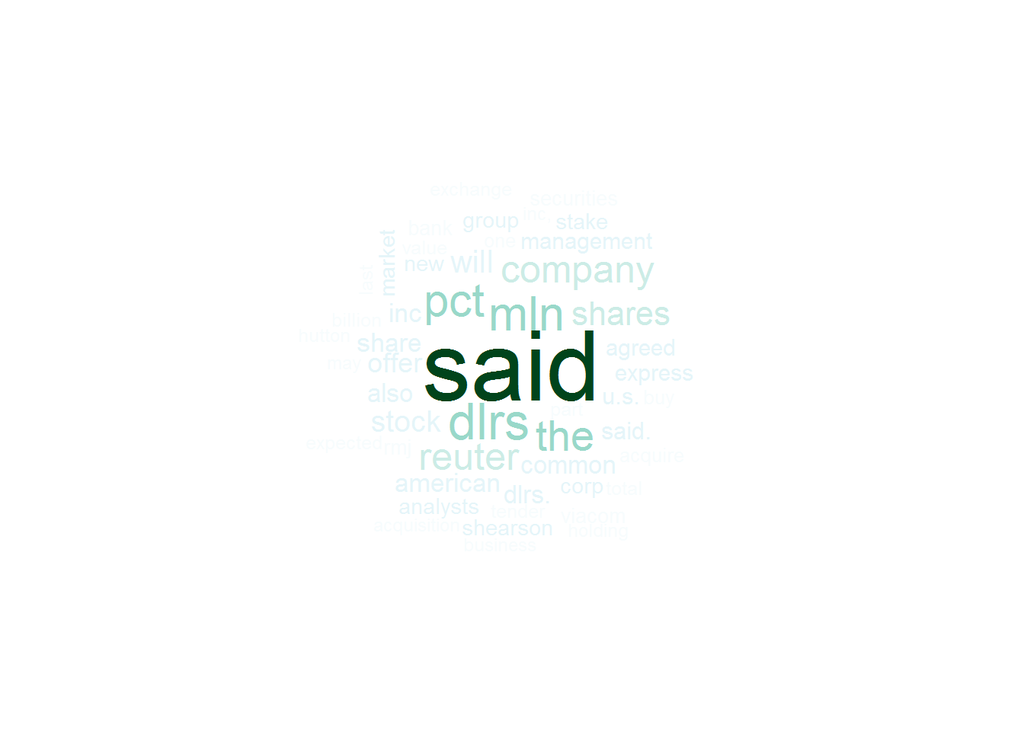

```r
library(wordcloud)
pal <- brewer.pal(9, "BuGn")

dm3 <- TermDocumentMatrix(dm3)
m1 <- as.matrix(dm3)
word.freq <- sort(rowSums(m1), decreasing = T)
wordcloud(words = names(word.freq), freq = word.freq, min.freq = 3, random.order = F,
    max.words = 50, colors = pal)
```

### Part D

```r
# d: find longest word and longest sentence from 10 largest docs longest
# sentence/word
sents <- tokenize_sentences(acq[[largest[1]]]$content)
word <- tokenize_words(acq[[largest[1]]]$content)
# longest word by chars
word[which.max(nchar(word))]
```

```
## [1] "capitalization"
```

```r
# longest sentence by chars
sents[which.max(nchar(sents))]
```

```
## [1] "stock is undervalued and does not fully reflect the performance"
```

```r
sents <- tokenize_sentences(acq[[largest[2]]]$content)
word <- tokenize_words(acq[[largest[2]]]$content)

# longest word by chars
word[which.max(nchar(word))]
```

```
## [1] "reorganization"
```

```r
# longest sentence by chars
sents[which.max(nchar(sents))]
```

```
## [1] "that could improve shearon s access to capital and help it meet"
```

```r
sents <- tokenize_sentences(acq[[largest[3]]]$content)
word <- tokenize_words(acq[[largest[3]]]$content)

# longest word by chars
word[which.max(nchar(word))]
```

```
## [1] "confidentiality"
```

```r
# longest sentence by chars
sents[which.max(nchar(sents))]
```

```
## [1] "one of the two groups vying for control of viacom international"
```

```r
sents <- tokenize_sentences(acq[[largest[4]]]$content)
word <- tokenize_words(acq[[largest[1]]]$content)

# longest word by chars
word[which.max(nchar(word))]
```

```
## [1] "capitalization"
```

```r
# longest sentence by chars
sents[which.max(nchar(sents))]
```

```
## [1] "will be purchased for securities and warrants to buy stock in a"
```

```r
sents <- tokenize_sentences(acq[[largest[1]]]$content)
word <- tokenize_words(acq[[largest[4]]]$content)

# longest word by chars
word[which.max(nchar(word))]
```

```
## [1] "shareholders"
```

```r
# longest sentence by chars
sents[which.max(nchar(sents))]
```

```
## [1] "stock is undervalued and does not fully reflect the performance"
```

```r
sents <- tokenize_sentences(acq[[largest[5]]]$content)
word <- tokenize_words(acq[[largest[5]]]$content)

# longest word by chars
word[which.max(nchar(word))]
```

```
## [1] "concentrating"
```

```r
# longest sentence by chars
sents[which.max(nchar(sents))]
```

```
## [1] "over an option held by nobel industrier sweden ab to acquire 33"
```

```r
sents <- tokenize_sentences(acq[[largest[6]]]$content)
word <- tokenize_words(acq[[largest[6]]]$content)

# longest word by chars
word[which.max(nchar(word))]
```

```
## [1] "servicemaster"
```

```r
# longest sentence by chars
sents[which.max(nchar(sents))]
```

```
## [1] "scheduled meeting today and was discussing the waste management"
```

```r
sents <- tokenize_sentences(acq[[largest[7]]]$content)
word <- tokenize_words(acq[[largest[7]]]$content)

# longest word by chars
word[which.max(nchar(word))]
```

```
## [1] "international"
```

```r
# longest sentence by chars
sents[which.max(nchar(sents))]
```

```
## [1] "made an offer for rmj when it was sold by security pacific corp"
```

```r
sents <- tokenize_sentences(acq[[largest[8]]]$content)
word <- tokenize_words(acq[[largest[8]]]$content)

# longest word by chars
word[which.max(nchar(word))]
```

```
## [1] "consolidated"
```

```r
# longest sentence by chars
sents[which.max(nchar(sents))]
```

```
## [1] "agreed to issue 7 8 mln treasury shares to acquire interests in"
```

```r
sents <- tokenize_sentences(acq[[largest[9]]]$content)
word <- tokenize_words(acq[[largest[9]]]$content)

# longest word by chars
word[which.max(nchar(word))]
```

```
## [1] "international"
```

```r
# longest sentence by chars
sents[which.max(nchar(sents))]
```

```
## [1] "raised the value of its offer for the viacom shares not held by"
```

```r
sents <- tokenize_sentences(acq[[largest[10]]]$content)
word <- tokenize_words(acq[[largest[10]]]$content)

# longest word by chars
word[which.max(nchar(word))]
```

```
## [1] "reorganization"
```

```r
# longest sentence by chars
sents[which.max(nchar(sents))]
```

```
## [1] "be exercisable at a price equal to 75 pct of its common stock s"
```

### Part E

```r
# e: Print a table of the length of each sentence in each of the 10
# documents.
library(formattable)
sents <- tokenize_sentences(acq[[largest[1]]]$content)
formattable(sapply(sents, wordcount))
```

```
##                          american express co remained silent on
##                                                               6
##      market rumors it would spinoff all or part of its shearson
##                                                              11
##   lehman brothers inc but some analysts said the company may be
##                                                              11
##   considering such a move because it is unhappy with the market
##                                                              11
##                                              value of its stock
##                                                               4
##         american express stock got a lift from the rumor as the
##                                                              11
##     market calculated a partially public shearson may command a
##                                                               9
##  good market value thereby boosting the total value of american
##                                                              10
##                                                         express
##                                                               1
##            the rumor also was accompanied by talk the financial
##                                                               9
##      services firm would split its stock and boost its dividend
##                                                              10
##       american express closed on the new york stock exchange at
##                                                              10
##                                 72 5 8 up 4 1 8 on heavy volume
##                                                              10
##         american express would not comment on the rumors or its
##                                                              10
##                                                  stock activity
##                                                               2
##            analysts said comments by the company at an analysts
##                                                               9
##   meeting tuesday helped fuel the rumors as did an announcement
##                                                              10
##                                 yesterday of management changes
##                                                               4
##          at the meeting company officials said american express
##                                                               8
## stock is undervalued and does not fully reflect the performance
##                                                              10
```

[output cut: 105 more lines]

```
##                                                               2
##               the value of the other components could command a
##                                                               9
##  higher multiple because they constitute a higher percentage of
##                                                               9
##             the total operating earnings of the company he said
##                                                               9
##            lewis said shearson contributed 316 mln in after tax
##                                                               9
##           operating earnings up from about 200 mln dlrs in 1985
##                                                              10
##
##                                                               0
##                                                          reuter
##                                                               1
```

```r
sents <- tokenize_sentences(acq[[largest[2]]]$content)
formattable(sapply(sents, wordcount))
```

```
##                               american express co rumored to be
##                                                               6
##   considering a spinoff of part of shearson lehman brothers inc
##                                                              10
##   said it is studying a range of options for its brokerage unit
##                                                              12
## that could improve shearon s access to capital and help it meet
##                                                              12
##                            broadening international competition
##                                                               3
##         in a joint statement american express and shearson said
##                                                               9
##         the actions under consideration are an integral part of
##                                                               9
##      american express worldwide financial services strategy and
##                                                               7
##       that the two companies have been having both internal and
##                                                              10
##                             external discussions on the matters
##                                                               5
##       american express said no decision has been reached on the
##                                                              10
##     strategic options and that it and shearson could ultimately
##                                                               9
##                  decide to follow growth plans already in place
##                                                               8
##             last week rumors circulated on wall street that the
##                                                               9
##   financial services giant was considering a spinoff of part of
##                                                              10
##        shearson and there was speculation it may be considering
##                                                               9
##                              selling a stake to a japanese firm
##                                                               7
##                                               analysts said the
##                                                               3
##  speculation also focused on american express selling 20 pct of
##                                                              10
##                     the profitable brokerage firm to the public
##                                                               7
```

[output cut: 83 more lines]

```
##                                                               8
##       acquisition last year is looking beyond its own walls for
##                                                              10
##         growth and positioning in the global market competition
##                                                               8
##             late last year shearson s takeover offer to the e f
##                                                              11
##       hutton group inc was rejected by hutton and analysts said
##                                                              10
## there had been speculation that shearson also was rebuffed when
##                                                              10
##               it approached another major wall street brokerage
##                                                               7
##                                                          reuter
##                                                               1
```

```r
sents <- tokenize_sentences(acq[[largest[3]]]$content)
formattable(sapply(sents, wordcount))
```

```
##                              investor sumner redstone who leads
##                                                               5
## one of the two groups vying for control of viacom international
##                                                              11
##   inc offered to sweeten his bid for the company by 1 50 dlrs a
##                                                              14
##                          share cash and 1 50 dlrs in securities
##                                                               8
##         in a filing with the securities and exchange commission
##                                                               9
##     redstone who controls dedham mass based national amusements
##                                                               8
##          inc a theater chain operator offered to raise the cash
##                                                              10
##  portion of its viacom offer to 42 dlrs a share from 40 50 dlrs
##                                                              14
##      redstone also raised the face value of the preferred stock
##                                                              10
##                       he is offering to 7 50 dlrs from six dlrs
##                                                              10
##          the redstone offer which is being made through arsenal
##                                                               9
##   holdings inc a national amusements subsidiary set up for that
##                                                              10
##      purpose which also give viacom shareholders one fifth of a
##                                                              10
##                share of arsenal common stock after the takeover
##                                                               8
##     viacom said earlier today it received revised takeover bids
##                                                               9
##        from redstone and mcv holdings inc a group led by viacom
##                                                              11
##  management which is competing with redstone for control of the
##                                                              10
##   company and already has a formal merger agreement with viacom
##                                                              10
##         the company did not disclose the details of the revised
##                                                              10
##   offers but said a special committee of its board would review
##                                                              11
```

[output cut: 57 more lines]

```
##                                                               9
##         last week the management group submitted what it called
##                                                               9
##       its last offer for the company valued at 3 1 mln dlrs and
##                                                              13
##    consisting of 38 50 dlrs a share cash preferred stock valued
##                                                              11
##             at eight dlrs a share and equity in the new company
##                                                              11
##                                                      redstone s
##                                                               2
##              previous offer had been valued at 3 2 billion dlrs
##                                                              10
##                                                          reuter
##                                                               1
```

```r
sents <- tokenize_sentences(acq[[largest[4]]]$content)
formattable(sapply(sents, wordcount))
```

```
##                            new jersey based overnight messenger
##                                                               5
##    purolator courier corp said it has agreed to be acquired for
##                                                              11
##                   about 265 mln dlrs by a company formed by e f
##                                                              11
##                                                  hutton lbo inc
##                                                               3
##        and certain managers of purolator s u s courier business
##                                                              10
##         analysts have said that purolator has been for sale for
##                                                              10
##                                                       some time
##                                                               2
##                    purolator announced earlier it was mulling a
##                                                               7
##  takeover bid but analysts wrongly predicted the offer was from
##                                                              10
##                                         another courier company
##                                                               3
##                     hutton lbo a wholly owned subsidiary of e f
##                                                               9
##                                                    hutton group
##                                                               2
##                       inc will be majority owner of the company
##                                                               8
##         hutton said the acquiring company pc acquisition inc is
##                                                               9
##   paying 35 dlrs cash per share for 83 pct of purolator s stock
##                                                              13
##                             in a tender offer to begin thursday
##                                                               7
##                                          the rest of the shares
##                                                               5
## will be purchased for securities and warrants to buy stock in a
##                                                              12
##         subsidiary of pc acquisition containing purolator s u s
##                                                               9
##                                              courier operations
##                                                               2
```

[output cut: 79 more lines]

```
##                                                              10
##        the tender offer will be conditioned on a minimum of two
##                                                              11
##  thirds of the common stock being tendered and not withdrawn to
##                                                              11
## the expiration of the offer as well as certain other conditions
##                                                              11
##        the offer will begin thursday subject to clearances from
##                                                               9
## the staff of the interstate commerce commission and will expire
##                                                              10
##             20 business days after commencement unless extended
##                                                               7
##                                                          reuter
##                                                               1
```

```r
sents <- tokenize_sentences(acq[[largest[5]]]$content)
formattable(sapply(sents, wordcount))
```

```
##                           sweden s wallenberg group fought back
##                                                               6
##      a bid by the london based swedish financier erik penser to
##                                                              11
##      secure a large stake in swedish match <smbs st> one of the
##                                                              12
##                  companies at the core of their business empire
##                                                               8
##       a statement issued by the wallenberg holding companies ab
##                                                               9
##    investor and forvaltnings ab providentia said they had taken
##                                                               9
## over an option held by nobel industrier sweden ab to acquire 33
##                                                              12
##                       pct of the voting rights in swedish match
##                                                               8
##       thre wallenbergs paid nobel industrier <nobl st> in which
##                                                               9
##    penser group has a 72 pct stake about 20 pct over the market
##                                                              13
##           price for the swedish match option the statement said
##                                                               9
##       swedish match s b shares open to foreign buyers closed at
##                                                              11
##                                            424 crowns on friday
##                                                               4
##                              the a shares with increased voting
##                                                               6
##      rights closed at 450 crowns for the restricted and 455 for
##                                                              11
##                                                 the free shares
##                                                               3
##       the statement said the deal increased investor s stake to
##                                                              10
## 49 4 pct of the voting rights and 14 8 pct of the share capital
##                                                              15
## while providentia is left holding 34 1 pct of the voting rights
##                                                              12
##              and 14 5 pct of the share capital in swedish match
##                                                              11
```

[output cut: 35 more lines]

```
##                                                              10
##                  any raid on the heart of their business empire
##                                                               9
##                but analysts say the wallenbergs position in the
##                                                               8
## electrical engineering firm asea ab <asea st> is also too small
##                                                              11
##     at 12 6 pct of the voting rights and there has been growing
##                                                              13
##    speculation that the group will be forced to sell off fringe
##                                                              11
##                        interests to protect its core activities
##                                                               6
##                                                          reuter
##                                                               1
```

```r
sents <- tokenize_sentences(acq[[largest[6]]]$content)
formattable(sapply(sents, wordcount))
```

```
##                            chemlawn corp <chem> could attract a
##                                                               6
##          higher bid than the 27 dlrs per share offered by waste
##                                                              11
##              management inc <wnx> wall street arbitrageurs said
##                                                               7
##                  shares of chemlawn shot up 11 5 8 to 29 3 8 in
##                                                              13
##     over the counter trading with 3 8 mln of the company s 10 1
##                                                              14
##                     mln shares changing hands by late afternoon
##                                                               7
##         this company could go for 10 times cash flow or 30 dlrs
##                                                              12
##      maybe 32 dollars depending on whether there is a competing
##                                                              10
##                                      bidder an arbitrageur said
##                                                               4
##                                 waste management s tender offer
##                                                               5
##             announced before the opening today expires march 25
##                                                               8
##             this is totally by surprise said debra strohmaier a
##                                                               9
##                                            chemlawn spokeswoman
##                                                               2
##                            the company s board held a regularly
##                                                               7
## scheduled meeting today and was discussing the waste management
##                                                               9
##                                                    announcement
##                                                               1
##                she said a statement was expected but it was not
##                                                              10
##                                  certain when it would be ready
##                                                               6
##       she was unable to say if there had been any prior contact
##                                                              12
##                 between waste management and chemlawn officials
##                                                               6
```

[output cut: 47 more lines]

```
##                                                               9
##      schlang said the company s profits are concentrated in the
##                                                              10
##                                                  fourth quarter
##                                                               2
##                 in 1986 chemlawn earned 1 19 dlrs per share for
##                                                              10
##               the full year and 2 58 dlrs in the fourth quarter
##                                                              11
##              morbelli noted chemlawn competes with thousands of
##                                                               7
##   individual entrepreuers who offer lawn and garden care sevice
##                                                               9
##                                                          reuter
##                                                               1
```

```r
sents <- tokenize_sentences(acq[[largest[7]]]$content)
formattable(sapply(sents, wordcount))
```

```
##                        <exco international plc> a subsidiary of
##                                                               6
##   british and commonwealth shipping co plc <bcom l> said it had
##                                                              11
##     agreed in principle to buy an 80 pct stake in <rmj holdings
##                                                              12
##                                     corp> for about 79 mln dlrs
##                                                               6
##     exco chairman richard lacy told reuters the acquisition was
##                                                               9
##  being made from bank of new york co inc <bk n> which currently
##                                                              13
##   holds a 50 1 pct and from rmj partners who hold the remainder
##                                                              13
##      bank of new york and the partners will retain about 10 pct
##                                                              12
##    each and these stakes will be bought over the next six years
##                                                              12
##         rmj is the holding company of rmj securities one of the
##                                                              11
##                                                     largest u s
##                                                               3
##                                   government securities brokers
##                                                               3
##      it is also involved in broking notes obligations and other
##                                                              10
##                                    instruments sponsored by u s
##                                                               5
##                                                federal agencies
##                                                               2
##                lacy said exco had been considering buying a u s
##                                                              10
##    government securities broker for the past four years and had
##                                                              10
## made an offer for rmj when it was sold by security pacific corp
##                                                              13
##                                                 <spc n> in 1985
##                                                               4
##                        rmj was then valued at about 50 mln dlrs
##                                                               9
```

[output cut: 23 more lines]

```
##                                                               7
##                       day and in london where it has 15 billion
##                                                               9
##     it was also given permission last week to open an office in
##                                                              12
##   tokyo where total market turnover had lifted rapidly to about
##                                                              10
##                                         five billion dlrs a day
##                                                               5
##     the acquisition would contribute between five and 10 pct of
##                                                              10
##            b and c s share earnings in 1987 on a proforma basis
##                                                              12
##                                                          reuter
##                                                               1
```

```r
sents <- tokenize_sentences(acq[[largest[8]]]$content)
formattable(sapply(sents, wordcount))
```

```
##                          <consolidated tvx mining corp> said it
##                                                               6
## agreed to issue 7 8 mln treasury shares to acquire interests in
##                                                              12
## three gold mining companies in brazil and an option to increase
##                                                              11
##                   the company s interest in a platinum property
##                                                               8
##          the company said the transactions will bring immediate
##                                                               8
##         production and earnings to consolidated tvx enhance its
##                                                               8
##   precious metal potential and is expected to improve cash flow
##                                                              10
##                               and earnings on a per share basis
##                                                               7
##                                        the company did not give
##                                                               5
##                                                specific figures
##                                                               2
##           consolidated tvx said it will acquire 29 pct of cmp a
##                                                              11
##  public gold mining company in which tvx already holds a 15 pct
##                                                              12
##              interest making tvx the largest single shareholder
##                                                               7
##       the company also agreed to acquire a 19 pct stake in novo
##                                                              12
##    astro a private company and a 16 pct interest in teles pires
##                                                              12
##                 mining increasing the tvx s ownership to 51 pct
##                                                               9
##           in addition consolidated tvx said it will acquire the
##                                                               9
##  right to add a 10 pct interest to a platinum property in which
##                                                              13
##                                it already owns a 29 4 pct stake
##                                                               8
##          cmp earned 11 mln canadian dlrs in 1986 and expects to
##                                                              11
```

[output cut: 9 more lines]

```
##                                                               8
##                                                       mining of
##                                                               2
##  eluvial surface material produced 25 000 ounces in 1986 and is
##                                                              11
##                       expected to produce 60 000 ounces in 1987
##                                                               8
##        it also said teles pires mining controls rights to a 350
##                                                              11
##  kilometer section of the teles pires river where one dredge is
##                                                              11
##               expected to produce 10 000 ounces of gold in 1987
##                                                              10
##                                                          reuter
##                                                               1
```

```r
sents <- tokenize_sentences(acq[[largest[9]]]$content)
formattable(sapply(sents, wordcount))
```

```
##                                viacom international inc said it
##                                                               5
##   received revised merger offers from <national amusements inc>
##                                                               8
##                                          and <mcv holdings inc>
##                                                               4
##      the company said the special committee plans to meet later
##                                                              10
##                                     today to review both offers
##                                                               5
##            viacom said national amusements arsenal holdings inc
##                                                               7
## raised the value of its offer for the viacom shares not held by
##                                                              13
##                              national amusements in three areas
##                                                               5
##                                       national amusements holds
##                                                               3
##                                      19 6 pct of viacom s stock
##                                                               7
##       the cash value of the offer was raised to 42 00 dlrs from
##                                                              13
##     the 40 50 dlrs a viacom share offered february 23 while the
##                                                              12
##      value of the fraction of a share of exchangeable preferred
##                                                              10
##  being offered was increased to 7 50 dlrs a share from six dlrs
##                                                              13
##  the interest rate to be used to increase the cash value of the
##                                                              13
##   merger if delayed beyond april 30 was raised to nine pct from
##                                                              12
##                               eight pct and 12 pct after may 31
##                                                               8
##            a viacom spokesman said the arsenal holdings s offer
##                                                               9
##   continues to include a 20 pct interest in arsenal for present
##                                                              11
##                                             viacom shareholders
##                                                               2
##             viacom said mcv holdings a group which includes the
##                                                               9
##    company s senior management and the equitable life assurance
##                                                               9
##   society of the united states raised the value of its offer by
##                                                              12
##     increasing the value of the preferred being offered to 8 50
##                                                              11
##    dlrs from 8 00 dlrs a share and raising the ownership in the
##                                                              13
## new company to be held by present viacom shareholders to 45 pct
##                                                              12
##                                                     from 25 pct
##                                                               3
##                  mcv called its previous offer made february 26
##                                                               8
##        the final proposed revision of its agreement with viacom
##                                                               9
##                                                          reuter
##                                                               1
```

```r
sents <- tokenize_sentences(acq[[largest[10]]]$content)
formattable(sapply(sents, wordcount))
```

```
##                              computer terminal systems inc said
##                                                               5
##       it has completed the sale of 200 000 shares of its common
##                                                              12
##   stock and warrants to acquire an additional one mln shares to
##                                                              11
##              <sedio n v > of lugano switzerland for 50 000 dlrs
##                                                              10
##          the company said the warrants are exercisable for five
##                                                               9
##                 years at a purchase price of 125 dlrs per share
##                                                              10
##          computer terminal said sedio also has the right to buy
##                                                              10
##  additional shares and increase its total holdings up to 40 pct
##                                                              11
##       of the computer terminal s outstanding common stock under
##                                                               9
##        certain circumstances involving change of control at the
##                                                               8
##                                                         company
##                                                               1
##     the company said if the conditions occur the warrants would
##                                                              10
## be exercisable at a price equal to 75 pct of its common stock s
##                                                              14
##      market price at the time not to exceed 1 50 dlrs per share
##                                                              13
##     computer terminal also said it sold the technolgy rights to
##                                                              10
##           its dot matrix impact technology including any future
##                                                               8
##         improvements to <woodco inc> of houston tex for 200 000
##                                                              10
##                                                            dlrs
##                                                               1
##               but it said it would continue to be the exclusive
##                                                              10
##                 worldwide licensee of the technology for woodco
##                                                               7
##      the company said the moves were part of its reorganization
##                                                              10
##      plan and would help pay current operation costs and ensure
##                                                              10
##                                                product delivery
##                                                               2
##         computer terminal makes computer generated labels forms
##                                                               7
##                          tags and ticket printers and terminals
##                                                               6
##                                                          reuter
##                                                               1
```

### Part F

```r
# f: remove punctuation and then display sentence
no_punct <- tm_map(acq, removePunctuation)
dataframe <- data.frame(text = unlist(sapply(no_punct, `[`, "content")), stringsAsFactors = F)
as.String(dataframe$text)
```

```
## Computer Terminal Systems Inc said
## it has completed the sale of 200000 shares of its common
## stock and warrants to acquire an additional one mln shares to
## Sedio NV of Lugano Switzerland for 50000 dlrs
##     The company said the warrants are exercisable for five
## years at a purchase price of 125 dlrs per share
##     Computer Terminal said Sedio also has the right to buy
## additional shares and increase its total holdings up to 40 pct
## of the Computer Terminals outstanding common stock under
## certain circumstances involving change of control at the
## company
##     The company said if the conditions occur the warrants would
## be exercisable at a price equal to 75 pct of its common stocks
## market price at the time not to exceed 150 dlrs per share
##     Computer Terminal also said it sold the technolgy rights to
## its Dot Matrix impact technology including any future
## improvements to Woodco Inc of Houston Tex for 200000
## dlrs But it said it would continue to be the exclusive
## worldwide licensee of the technology for Woodco
##     The company said the moves were part of its reorganization
## plan and would help pay current operation costs and ensure
## product delivery
##     Computer Terminal makes computer generated labels forms
## tags and ticket printers and terminals
##  Reuter
## Ohio Mattress Co said its first
## quarter ending February 28 profits may be below the 24 mln
## dlrs or 15 cts a share earned in the first quarter of fiscal
## 1986
##     The company said any decline would be due to expenses
## related to the acquisitions in the middle of the current
## quarter of seven licensees of Sealy Inc as well as 82 pct of
## the outstanding capital stock of Sealy
##     Because of these acquisitions it said first quarter sales
## will be substantially higher than last years 671 mln dlrs
##     Noting that it typically reports first quarter results in
## late march said the report is likely to be issued in early
## April this year
##     It said the delay is due to administrative considerations
## including conducting appraisals in connection with the
```

[output cut: 863 more lines]

```
## are looking to acquisitions and joint ventures when they look
## like the fastest and most promising routes to the growth
## markets weve identified
##     Not very long ago Union Carbide had the attitude that if
## we couldnt do it ourselves it wasnt worth doing Or if it
## was worth doing we had to go it alone Lichtenberger
## explained
##     He said there are times when exploiting a profitable
## market is done best with a partner Nor do we see any need to
## plow resources into a technology we may not have if we can link
## up profitably with someone who is already there
##     He said Carbide has extended its catalyst business that way
## and is now extending its specialty chemicals business in the
## same way
##  Reuter
```

### Part G

```r
# g: pring Wordnet POS tags
library(wordnet)
library(openNLP)

tokenized <- tokenize_words(as.String(dataframe$text))

s <- as.String(dataframe$text)


posTagger <- Maxent_POS_Tag_Annotator(language = "en", probs = F, model = NULL)


sent_token_annotator <- Maxent_Sent_Token_Annotator()
word_token_annotator <- Maxent_Word_Token_Annotator()
pos_tag_annotator <- Maxent_POS_Tag_Annotator()

y1 <- annotate(s, c(sent_token_annotator, word_token_annotator))

t <- annotate(s, posTagger, y1)
head(t, n = 30)
```

```
##  id type     start end   features
##   1 sentence     1 45573 constituents=<<integer,7634>>
##   2 word         1     8 POS=NNP
##   3 word        10    17 POS=NNPS
##   4 word        19    25 POS=NNPS
##   5 word        27    29 POS=NNP
##   6 word        31    34 POS=VBD
##   7 word        36    37 POS=PRP
##   8 word        39    41 POS=VBZ
##   9 word        43    51 POS=VBN
##  10 word        53    55 POS=DT
##  11 word        57    60 POS=NN
##  12 word        62    63 POS=IN
##  13 word        65    70 POS=CD
##  14 word        72    77 POS=NNS
```

[output cut: 16 more lines]

### Part H

```r
# h: analyze word freq using zipfR
require(zipfR)
# ?zipfR

tdm <- TermDocumentMatrix(acq)
# for clarity we limit the size of this for the print our
```

```r
temp <- inspect(tdm)
```

```r
freq <- data.frame(ST = rownames(temp), Freq = rowSums(temp))
row.names(freq) <- NULL
head(freq)
```

```
##            ST Freq
## 1      -laval    1
## 2 "(american)    1
## 3    "...that    1
## 4        "any    1
## 5    "bridge"    1
## 6     "final"    1
```

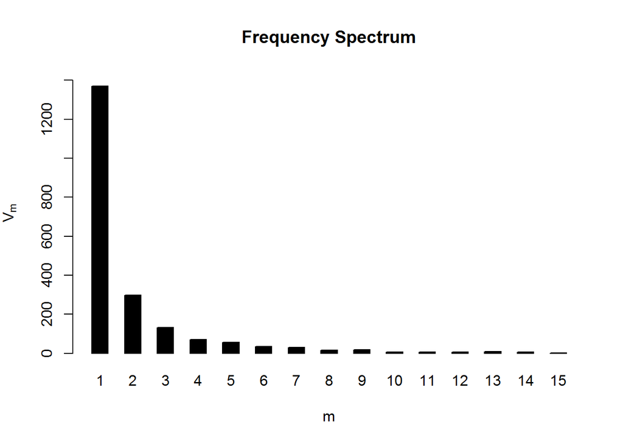

```r
mytfl <- tfl(freq$Freq, freq$ST)
acq.spc <- tfl2spc(mytfl)

# frequency spectrum
plot(acq.spc)
```

```r
summary(acq.spc)
```

```
## zipfR object for frequency spectrum
## Sample size:     N  = 6198
## Vocabulary size: V  = 2103
## Class sizes:     Vm = 1370 297 131 70 55 34 31 15 ...
```

```r
acq.fzm <- lnre("fzm", acq.spc)
summary(acq.fzm)
```

```
## finite Zipf-Mandelbrot LNRE model.
## Parameters:
##    Shape:          alpha = 0.5297333
##    Lower cutoff:       A = 1.02997e-18
##    Upper cutoff:       B = 0.003838884
##  [ Normalization:      C = 6.43298 ]
## Population size: S = 40997821168
## Sampling method: Poisson, with exact calculations.
##
## Parameters estimated from sample of size N = 6198:
##                 V      V1     V2     V3 V4    V5
##    Observed: 2103 1370.00 297.00 131.00 70 55.00 ...
##    Expected: 2103 1236.53 290.75 142.49 88 61.08 ...
##
## Goodness-of-fit (multivariate chi-squared test):
##          X2 df            p
##    402.5592 13 6.442116e-78
```

```r
# Vocab Growth
Vm(acq.fzm, 1)/N(acq.spc)
```

```
## [1] 0.221039
```

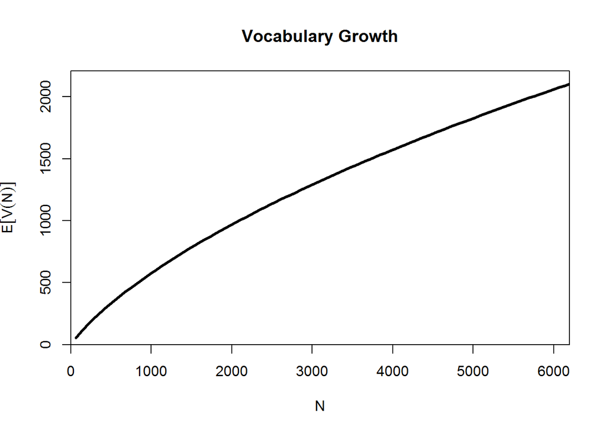

```r
sample.sizes <- floor(N(acq.spc)/100 * (1:100))
acq.vgc <- vgc.interp(acq.spc, sample.sizes)
plot(acq.vgc)
```

## Part C

We create the function `doc_search` to get the document, word index, and line number of a particular string.

```r
# install.packages('quanteda') library(quanteda)

doc_search <- function(data, search) {
    mycorpus <- corpus(data)
    result <- kwic(mycorpus, search, window = 3)
    result[[1]] <- gsub("reut-000", "", result[[1]])
    result[[1]] <- gsub(".xml", "", result[[1]])
    doc_number <- as.numeric(result[[1]])  # document number
    word_index <- result[[2]]  # word index in document
    word <- result[[4]][[1]]  # word searching for
    line_index <- list()
    docs <- unique(doc_number)
    out <- capture.output(cat(mycorpus[docs]))
    line <- grep(search, out, ignore.case = T)
    line_index <- list(line_index, as.numeric(line))
    df = data.frame(doc_number, word_index, line)
    word_used = cat("Searching documents for:", word, "\n")
    return(df)
}

doc_search(acq, "because")
```

```
## Searching documents for: Because
```

```
##   doc_number word_index line
## 1          2         78    9
## 2          7         34   20
## 3          7        625   82
## 4         26        276    9
## 5         26        338   20
## 6         30        366   82
```

```r
doc_search(acq, "Mattress")
```

```
## Searching documents for: Mattress
```

```
##   doc_number word_index line
## 1          2          2    1
```

```r
doc_search(acq, "appraisals")
```

```
## Searching documents for: appraisals
```

```
##   doc_number word_index line
## 1          2        138   15
```

## Part D

This porject has been essential to our education in Data Science. SPecifically, text is by far the most prolific type of data. Humans generate trillions of bytes of text everyday from speech to writing. The ability to manipulate and analyze this is key to the study of data science. Data science hopes to provide useful insight to all sorts of phenomena through the exploitation of descriptive data. If the vast majority of available data is text than understanding text analytics is vital to any education in data science. In this excercise we have had to manipulate corpora to extract basic statistical data from texts. While the excercises in this project have been generally basic they are a an important stepping stone to more powerful text analytics, such as sentiment analysis, topic modeling, language modeling, keyword extraction, and more. If we hope to learn to extract latent meaning from texts the tools we learned in this project, such as word frequency, document term matricies, word associations, term extraction, among others, are essential to this education.